# IE2152 Statistics for IE Project Final Project

```r
#Plot the probabilities of each cell from standard normal distribution with k=7 equal bins.
x <- seq(-2,2,0.01)
plot(x,dnorm(x),type="l",yaxt='n',xlab='z',ylab='')
abline(v = z, col = "blue")
```

```r
#Plot the probabilities of each cell from normal distribution with k=7 equal bins.
plot(x,dnorm(x, xbar, sd),type="l",yaxt='n',ylab='')
abline(v = interval, col = "blue")
```

```r
#Observed frequencies of class i are entered into a table and expected frequencies are calculated for pi=1/7.
cut<-cut(0, interval, right=F)
voltage.freq<- c(21,3,1,3,0,2,1)
names(voltage.freq)<-levels(cut)
voltage.prob<-rep(1/k,k)
n<-42
voltage.exp<-n*voltage.prob

#View the observed and expected frequencies together.
cbind(Observed=voltage.freq,Expected=voltage.exp)
```

```
##                      Observed Expected
## [-Inf,-2.88e+07)           21        6
## [-2.88e+07,1.71e+07)        3        6
## [1.71e+07,5.23e+07)         1        6
## [5.23e+07,8.53e+07)         3        6
## [8.53e+07,1.21e+08)         0        6
## [1.21e+08,1.66e+08)         2        6
## [1.66e+08, Inf)             1        6
```

```r
#We do the Goodness of Fit test with 7-2-1=4 degrees of freedom since two parameters of normal dist. is estimated.
#We need to readjust the degrees of freedom by using the following functions.
voltage.Xsq<-chisq.test(voltage.freq,p=voltage.prob)
voltage.Xsq$parameter <- c(df=4)
voltage.Xsq$p.value <- pchisq(voltage.Xsq$statistic, df=4, lower=F)

#We can view the result of the test, observed and expected frequencies.
voltage.Xsq
```

```
##
##  Chi-squared test for given probabilities
##
## data:  voltage.freq
## X-squared = 74, df = 4, p-value = 0.000000000000003
```

```r
voltage.table<-rbind(observed=voltage.Xsq$observed, expected=voltage.Xsq$expected); t(voltage.table)
```

```
##                      observed expected
## [-Inf,-2.88e+07)           21    4.429
## [-2.88e+07,1.71e+07)        3    4.429
## [1.71e+07,5.23e+07)         1    4.429
## [5.23e+07,8.53e+07)         3    4.429
## [8.53e+07,1.21e+08)         0    4.429
## [1.21e+08,1.66e+08)         2    4.429
## [1.66e+08, Inf)             1    4.429
```

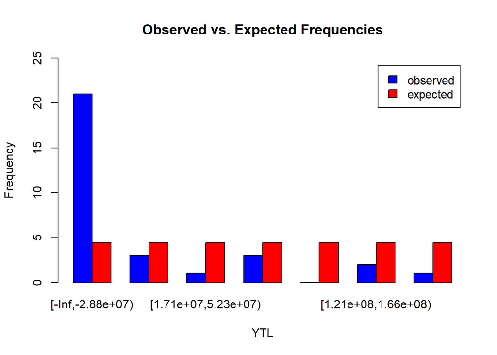

```r
barplot(voltage.table,ylim=c(0,25),beside=TRUE,legend=TRUE,main="Observed vs. Expected Frequencies",col=c("blue", "red"),xlab="YTL", ylab="Frequency")
```

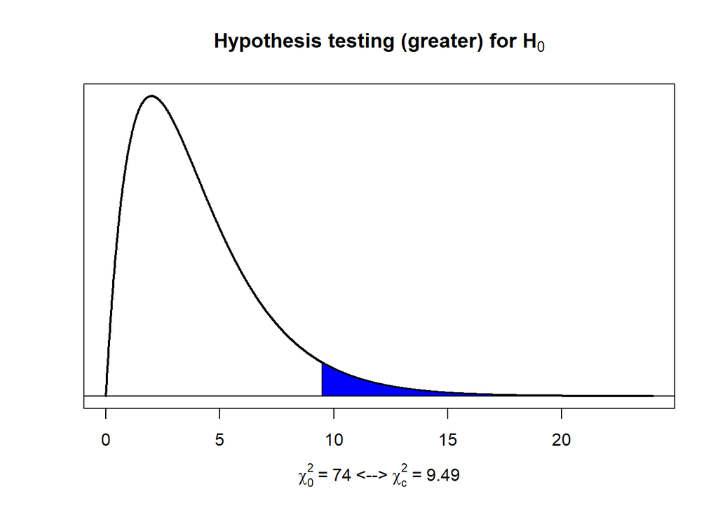

```r
#We can plot the hypothesis testing for goodness of fit using plotvar.hypothesis function that we defined before.
plotvar.hypothesis(voltage.Xsq$statistic,alpha=0.05,df1=4,type='c',alt='g')
```

```r
#Write your codes here. Their results will appear after knitting the markdown file.

#For GNP

k <- 7
xbar <- mean(data_22$GNP)
sd <- sd(data_22$GNP)
z <- qnorm(0:k/k); z
```

```
## [1]    -Inf -1.0676 -0.5659 -0.1800  0.1800  0.5659  1.0676     Inf
```

```r
interval <- xbar+z*sd; interval
```

```
## [1]        -Inf -1870869590   363738788  2082996201  3686822942  5406080354
## [7]  7640688732         Inf
```

```r
gftGNP<-(data_22$GNP)
gftGNP.breaks <- seq(3800,18334799700,by=2291849487)
gftGNP.cut<- cut(gftD,gftGNP.breaks,right = F)
gftGNP.freq<- table((gftGNP.cut))
gftGNP.freq
```

```
##
##  [3.8e+03,2.29e+09) [2.29e+09,4.58e+09) [4.58e+09,6.88e+09) [6.88e+09,9.17e+09)
##                  33                   0                   0                   0
## [9.17e+09,1.15e+10) [1.15e+10,1.38e+10)  [1.38e+10,1.6e+10)  [1.6e+10,1.83e+10)
##                   0                   0                   0                   0
```

```r
#Plot the probabilities of each cell from standard normal distribution with k=7 equal bins.
x <- seq(-2,2,0.01)
plot(x,dnorm(x),type="l",yaxt='n',xlab='z',ylab='')
abline(v = z, col = "blue")
```

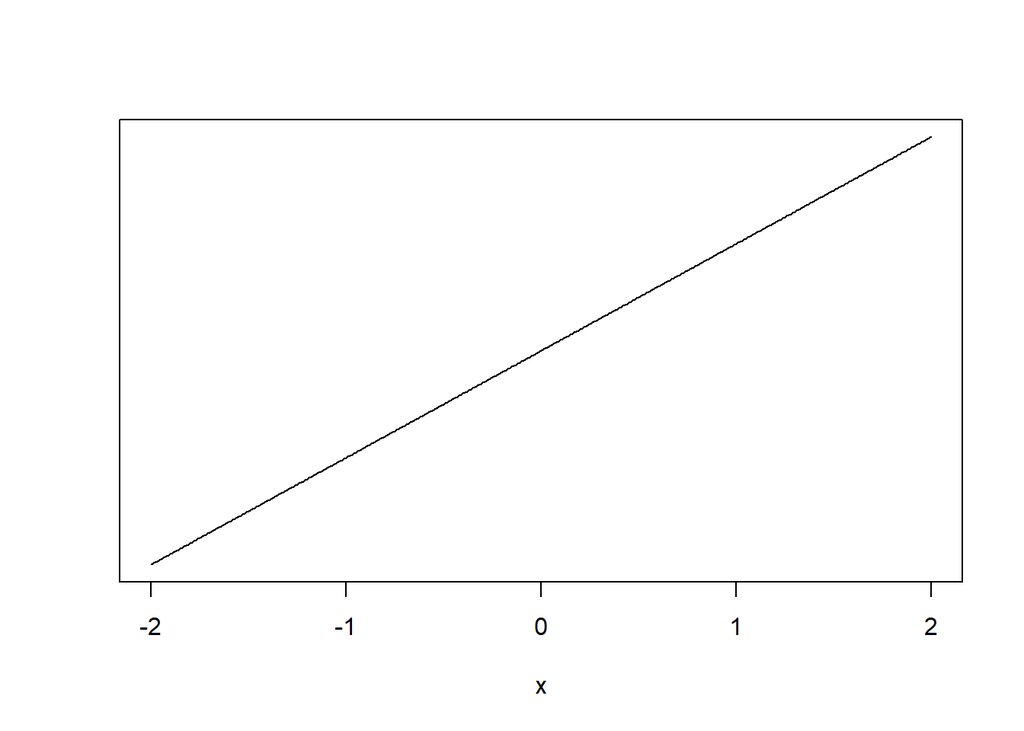

```r
#Plot the probabilities of each cell from normal distribution with k=7 equal bins.
plot(x,dnorm(x, xbar, sd),type="l",yaxt='n',ylab='')
abline(v = interval, col = "blue")
```

```r
#Observed frequencies of class i are entered into a table and expected frequencies are calculated for pi=1/7.
cut<-cut(0, interval, right=F)
voltage.freq<- c(27,3,5,3,1,1,2)
names(voltage.freq)<-levels(cut)
voltage.prob<-rep(1/k,k)
n<-42
voltage.exp<-n*voltage.prob

#View the observed and expected frequencies together.
cbind(Observed=voltage.freq,Expected=voltage.exp)
```

```
##                      Observed Expected
## [-Inf,-1.87e+09)           27        6
## [-1.87e+09,3.64e+08)        3        6
## [3.64e+08,2.08e+09)         5        6
## [2.08e+09,3.69e+09)         3        6
## [3.69e+09,5.41e+09)         1        6
## [5.41e+09,7.64e+09)         1        6
## [7.64e+09, Inf)             2        6
```

```r
#We do the Goodness of Fit test with 7-2-1=4 degrees of freedom since two parameters of normal dist. is estimated.
#We need to readjust the degrees of freedom by using the following functions.
voltage.Xsq<-chisq.test(voltage.freq,p=voltage.prob)
voltage.Xsq$parameter <- c(df=4)
voltage.Xsq$p.value <- pchisq(voltage.Xsq$statistic, df=4, lower=F)

#We can view the result of the test, observed and expected frequencies.
voltage.Xsq
```

```
##
##  Chi-squared test for given probabilities
##
## data:  voltage.freq
## X-squared = 88, df = 4, p-value <0.0000000000000002
```

```r
voltage.table<-rbind(observed=voltage.Xsq$observed, expected=voltage.Xsq$expected); t(voltage.table)
```

```
##                      observed expected
## [-Inf,-1.87e+09)           27        6
## [-1.87e+09,3.64e+08)        3        6
## [3.64e+08,2.08e+09)         5        6
## [2.08e+09,3.69e+09)         3        6
## [3.69e+09,5.41e+09)         1        6
## [5.41e+09,7.64e+09)         1        6
## [7.64e+09, Inf)             2        6
```

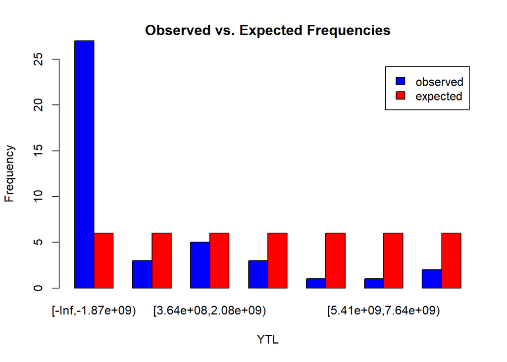

```r
barplot(voltage.table,ylim=c(0,25),beside=TRUE,legend=TRUE,main="Observed vs. Expected Frequencies",col=c("blue", "red"),xlab="YTL", ylab="Frequency")
```

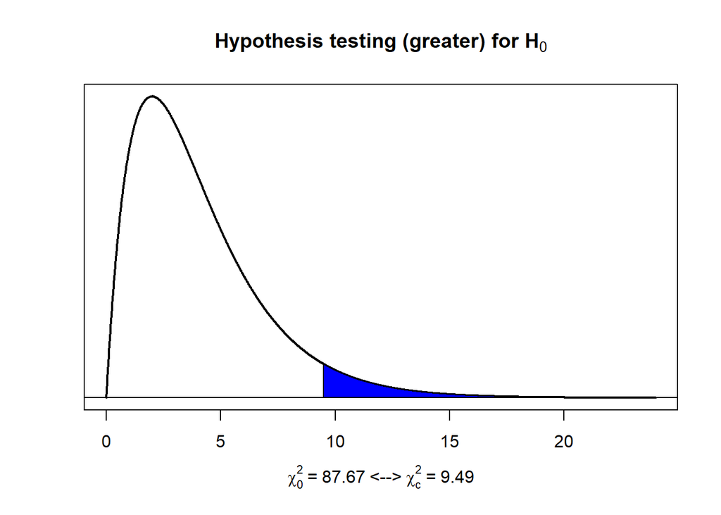

```r
#We can plot the hypothesis testing for goodness of fit using plotvar.hypothesis function that we defined before.
plotvar.hypothesis(voltage.Xsq$statistic,alpha=0.05,df1=4,type='c',alt='g')
```

```r
#Write your codes here. Their results will appear after knitting the markdown file.

#Define the observed contingency table of CE, PE, OCE, D and GNP
contce <- c(data_22$CE)
contpe <- c(data_22$PE)
contoce <- c(data_22$OCE)
contd <- c(data_22$D)
contgnp <- c(data_22$GNP)

contall <- rbind(contce,contpe,contoce,contd,contgnp); addmargins(contall)
```

```
##
## contce   668.0  776.6  1314.3  2422.0  3795.6  4401.0  7575  12406  20168
## contpe   553.3  627.1   991.5  1971.1  3012.1  3271.8  6032  10263  17230
## contoce  114.7  149.5   322.8   450.9   783.5  1129.2  1543   2143   2938
## contd    143.6  124.9   198.9   325.8   548.6   757.9  1262   2538   3598
## contgnp 3810.5 5251.0  8504.5 17541.5 24525.6 34148.0 47040  73938 126874
## Sum     5290.1 6929.1 11332.0 22711.3 32665.4 43707.9 63452 101288 170808
##
## contce   32418  45967  75887  129114  247636  400164  654652 1162463  3037804
## contpe   27676  39041  65664  108093  206943  341749  557737  973752  2669305
## contoce   4742   6925  10223   21021   40693   58415   96915  188710   368498
## contd     4982   5980   8565   12550   20140   46975   84150  126100   310266
## contgnp 195143 289106 485848  910059 1547793 2273698 4037702 6941224 16581567
## Sum     264961 387019 646187 1180837 2063205 3121001 5431156 9392250 22967440
##
## contce   6263359 10671604  20375174  39372739  75952566 129126691  162283574
## contpe   5509474  9275954  17756985  34074324  65793169 113053505  137522687
## contoce   753886  1395650   2618188   5298414  10159397  16073186   24760887
## contd     747500  1247500   4325000  11000000  22421093  24275000   34870000
## contgnp 35178972 63576940 117683404 233660805 407069775 651380055 1070424473
## Sum     48453191 86167648 162758751 323406282 581396000 933908437 1429861620
##
## contce   220646137  334498045  436157692  571203866  742526704  932560259
## contpe   186722955  285819432  374790266  483139434  624001847  756015537
## contoce   33923183   48678614   61367426   88064432  118524857  176544722
## contd     54000000   68918000   78000000   80145649  118843456  120047875
## contgnp 1418703264 1907070964 2520806747 3143699612 4101387191 4671255886
## Sum     1913995538 2644985054 3471122132 4366252993 5705284054 6656424279
##
## contce  1024958716 1103415415 1140049984 1159028230 1199857540  1295770450
## contpe   866264413  936237771  947401504  989460966 1016009249  1097304837
## contoce  158694303  167177644  192648480  169567264  183848292   198465613
## contd    146813407  167395579  163327203  199979873  194687300   201795988
## contgnp 5128334134 5415280699 5649534936 6559174529 6915831629  7579403276
## Sum     7325064973 7789507108 8092962107 9077210863 9510234010 10372740164
##
## contce   1465520572  1566222876  1680388904  1956564794  2340681611
## contpe   1240105108  1324714693  1425718505  1645246451  1965616053
## contoce   225415464   241508183   254670399   311318343   375065558
## contd     227517948   240860181   252444741   305176268   170498906
## contgnp  8840388008 10210731660 11605460378 14551761179 18334799699
## Sum     11998947099 13584037594 15218682927 18770067035 23186661828
##                  Sum
## contce   19619937132
## contpe   16552589029
## contoce   3067348103
## contd     2889967673
## contgnp 121166201989
## Sum     163296043926
```

```r
contall.prop <- prop.table(contall)

#Compute ui, vj and expected frequencies.
u <- rowSums(contall.prop); u
```

```
##  contce  contpe contoce   contd contgnp
## 0.12015 0.10137 0.01878 0.01770 0.74200
```

```r
v <- colSums(contall.prop); v
```

```
##  [1] 0.00000003240 0.00000004243 0.00000006940 0.00000013908 0.00000020004
##  [6] 0.00000026766 0.00000038857 0.00000062027 0.00000104600 0.00000162258
## [11] 0.00000237005 0.00000395715 0.00000723126 0.00001263475 0.00001911253
## [16] 0.00003325957 0.00005751670 0.00014064909 0.00029671993 0.00052767750
## [21] 0.00099670970 0.00198049061 0.00356038019 0.00571911244 0.00875625389
## [26] 0.01172101597 0.01619748397 0.02125662109 0.02673826559 0.03493828703
## [31] 0.04076292431 0.04485757767 0.04770175027 0.04956006228 0.05558745114
## [36] 0.05823921867 0.06352107445 0.07347971703 0.08318656881 0.09319688684
## [41] 0.11494502000 0.14199157108
```

```r
E <- sum(contall)*u%o%v; addmargins(E)
```

```
##
## contce   635.60  832.5  1361.5  2728.8  3924.7  5251.5  7624  12170  20522
## contpe   536.23  702.4  1148.7  2302.1  3311.1  4430.5  6432  10267  17314
## contoce   99.37  130.2   212.9   426.6   613.6   821.0  1192   1903   3208
## contd     93.62  122.6   200.6   401.9   578.1   773.5  1123   1793   3023
## contgnp 3925.27 5141.4  8408.4 16851.9 24237.8 32431.4 47082  75156 126740
## Sum     5290.10 6929.1 11332.0 22711.3 32665.4 43707.9 63452 101287 170808
##
## contce   31835  46500  77639  141877  247893  374987  652551 1128474  2759526
## contpe   26858  39230  65501  119696  209138  316362  550532  952050  2328107
## contoce   4977   7270  12138   22181   38755   58625  102019  176424   431420
## contd     4689   6849  11436   20898   36514   55235   96119  166221   406471
## contgnp 196602 287170 479473  876185 1530905 2315793 4029936 6969080 17041916
## Sum     264961 387019 646187 1180837 2063205 3121001 5431156 9392250 22967440
##
## contce   5821626 10352999  19555382  38857101  69854436 112208627  171797151
## contpe   4911483  8734429  16498126  32782247  58933510  94666118  144938672
## contoce   910143  1618571   3057256   6074854  10920925  17542509   26858479
## contd     857511  1524971   2880459   5723554  10289384  16528050   25305291
## contgnp 35952427 63936679 120767529 239968526 431397746 692963133 1060962028
## Sum     48453191 86167648 162758751 323406282 581396000 933908437 1429861620
##
## contce   229965596  317793617  417053569  524603090  685486995  799766012
## contpe   194013160  268110296  351852113  442587522  578319107  674731934
## contoce   35952436   49683322   65201456   82015568  107167888  125034079
## contd     33873357   46810205   61430948   77272723  100970520  117803534
## contgnp 1420190988 1962587615 2575584045 3239774090 4233339544 4939088721
## Sum     1913995538 2644985054 3471122132 4366252993 5705284054 6656424279
##
## contce   880102854  935905341  972365306 1090622297 1142649809  1246279487
## contpe   742509048  789587468  820347343  920116234  964009852  1051438240
## contoce  137593806  146317873  152017963  170506063  178639957   194841247
## contd    129636949  137856516  143226978  160645937  168309459   183573852
## contgnp 5435222316 5779839909 6005004517 6735320333 7056624933  7696607338
## Sum     7325064973 7789507108 8092962107 9077210863 9510234010 10372740164
##
## contce   1441667429  1632115250  1828517061  2255214066  2785865698
## contpe   1216279558  1376953086  1542649767  1902637677  2350328122
## contoce   225387871   255162164   285867294   352576389   435537576
## contd     212354007   240406495   269335990   332187392   410351050
## contgnp  8903258235 10079400599 11292312816 13927451511 17204579382
## Sum     11998947099 13584037594 15218682927 18770067035 23186661828
##                  Sum
## contce   19619937132
## contpe   16552589029
## contoce   3067348103
## contd     2889967673
## contgnp 121166201989
## Sum     163296043926
```

```r
#We do the Goodness of Fit test with (42-1)*(5-1)=164 degrees of freedom
Xsq <- chisq.test(contall)

#We can view the result of the test, observed and expected frequencies.
Xsq
```

```
##
##  Pearson's Chi-squared test
##
## data:  contall
## X-squared = 965698073, df = 164, p-value <0.0000000000000002
```

```r
cont.table<-rbind(observed=Xsq$observed, expected=Xsq$expected); cont.table
```

```
##            [,1]   [,2]   [,3]    [,4]    [,5]    [,6]  [,7]  [,8]   [,9]  [,10]
## contce   668.00  776.6 1314.3  2422.0  3795.6  4401.0  7575 12406  20168  32418
## contpe   553.30  627.1  991.5  1971.1  3012.1  3271.8  6032 10263  17230  27676
## contoce  114.70  149.5  322.8   450.9   783.5  1129.2  1543  2143   2938   4742
## contd    143.60  124.9  198.9   325.8   548.6   757.9  1262  2538   3598   4982
## contgnp 3810.50 5251.0 8504.5 17541.5 24525.6 34148.0 47040 73938 126874 195143
## contce   635.60  832.5 1361.5  2728.8  3924.7  5251.5  7624 12170  20522  31835
## contpe   536.23  702.4 1148.7  2302.1  3311.1  4430.5  6432 10267  17314  26858
## contoce   99.37  130.2  212.9   426.6   613.6   821.0  1192  1903   3208   4977
## contd     93.62  122.6  200.6   401.9   578.1   773.5  1123  1793   3023   4689
## contgnp 3925.27 5141.4 8408.4 16851.9 24237.8 32431.4 47082 75156 126740 196602
##          [,11]  [,12]  [,13]   [,14]   [,15]   [,16]   [,17]    [,18]    [,19]
## contce   45967  75887 129114  247636  400164  654652 1162463  3037804  6263359
## contpe   39041  65664 108093  206943  341749  557737  973752  2669305  5509474
## contoce   6925  10223  21021   40693   58415   96915  188710   368498   753886
## contd     5980   8565  12550   20140   46975   84150  126100   310266   747500
## contgnp 289106 485848 910059 1547793 2273698 4037702 6941224 16581567 35178972
## contce   46500  77639 141877  247893  374987  652551 1128474  2759526  5821626
## contpe   39230  65501 119696  209138  316362  550532  952050  2328107  4911483
## contoce   7270  12138  22181   38755   58625  102019  176424   431420   910143
## contd     6849  11436  20898   36514   55235   96119  166221   406471   857511
## contgnp 287170 479473 876185 1530905 2315793 4029936 6969080 17041916 35952427
##            [,20]     [,21]     [,22]     [,23]     [,24]      [,25]      [,26]
## contce  10671604  20375174  39372739  75952566 129126691  162283574  220646137
## contpe   9275954  17756985  34074324  65793169 113053505  137522687  186722955
## contoce  1395650   2618188   5298414  10159397  16073186   24760887   33923183
## contd    1247500   4325000  11000000  22421093  24275000   34870000   54000000
## contgnp 63576940 117683404 233660805 407069775 651380055 1070424473 1418703264
## contce  10352999  19555382  38857101  69854436 112208627  171797151  229965596
## contpe   8734429  16498126  32782247  58933510  94666118  144938672  194013160
## contoce  1618571   3057256   6074854  10920925  17542509   26858479   35952436
## contd    1524971   2880459   5723554  10289384  16528050   25305291   33873357
## contgnp 63936679 120767529 239968526 431397746 692963133 1060962028 1420190988
##              [,27]      [,28]      [,29]      [,30]      [,31]      [,32]
## contce   334498045  436157692  571203866  742526704  932560259 1024958716
## contpe   285819432  374790266  483139434  624001847  756015537  866264413
## contoce   48678614   61367426   88064432  118524857  176544722  158694303
## contd     68918000   78000000   80145649  118843456  120047875  146813407
## contgnp 1907070964 2520806747 3143699612 4101387191 4671255886 5128334134
## contce   317793617  417053569  524603090  685486995  799766012  880102854
```

[output cut: 11 more lines]

```
## contpe   789587468  820347343  920116234  964009852 1051438240 1216279558
## contoce  146317873  152017963  170506063  178639957  194841247  225387871
## contd    137856516  143226978  160645937  168309459  183573852  212354007
## contgnp 5779839909 6005004517 6735320333 7056624933 7696607338 8903258235
##               [,39]       [,40]       [,41]       [,42]
## contce   1566222876  1680388904  1956564794  2340681611
## contpe   1324714693  1425718505  1645246451  1965616053
## contoce   241508183   254670399   311318343   375065558
## contd     240860181   252444741   305176268   170498906
## contgnp 10210731660 11605460378 14551761179 18334799699
## contce   1632115250  1828517061  2255214066  2785865698
## contpe   1376953086  1542649767  1902637677  2350328122
## contoce   255162164   285867294   352576389   435537576
## contd     240406495   269335990   332187392   410351050
## contgnp 10079400599 11292312816 13927451511 17204579382
```

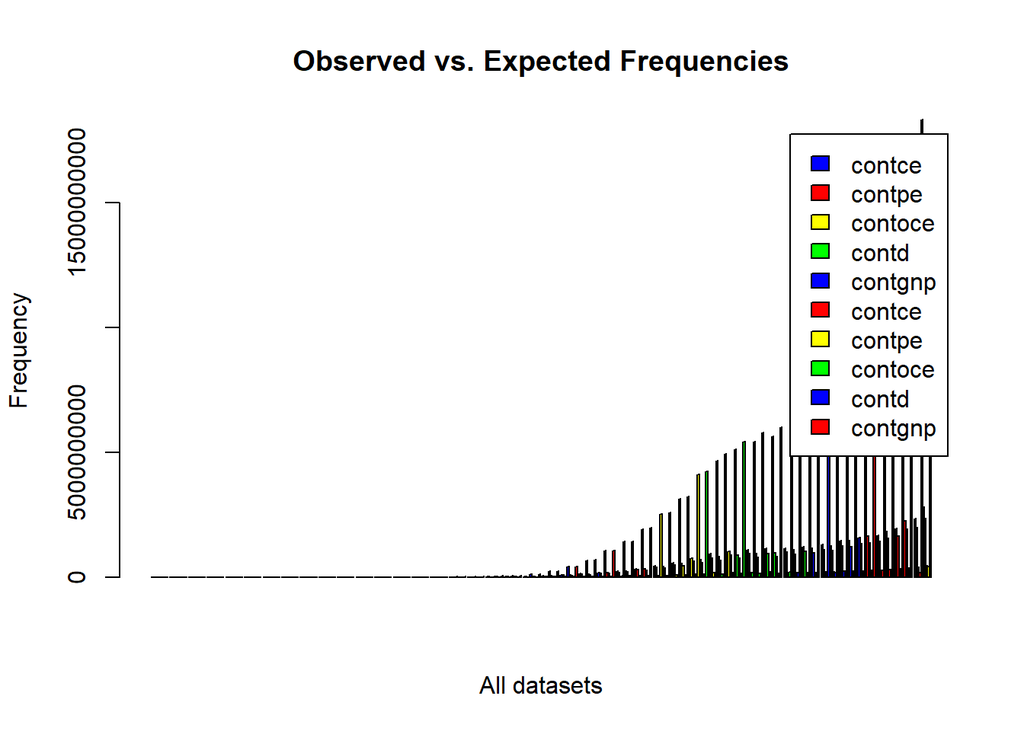

```r
barplot(cont.table,beside=TRUE,legend=TRUE,main="Observed vs. Expected Frequencies",
        col=c("blue", "red","yellow","green"),xlab="All datasets", ylab="Frequency")
```

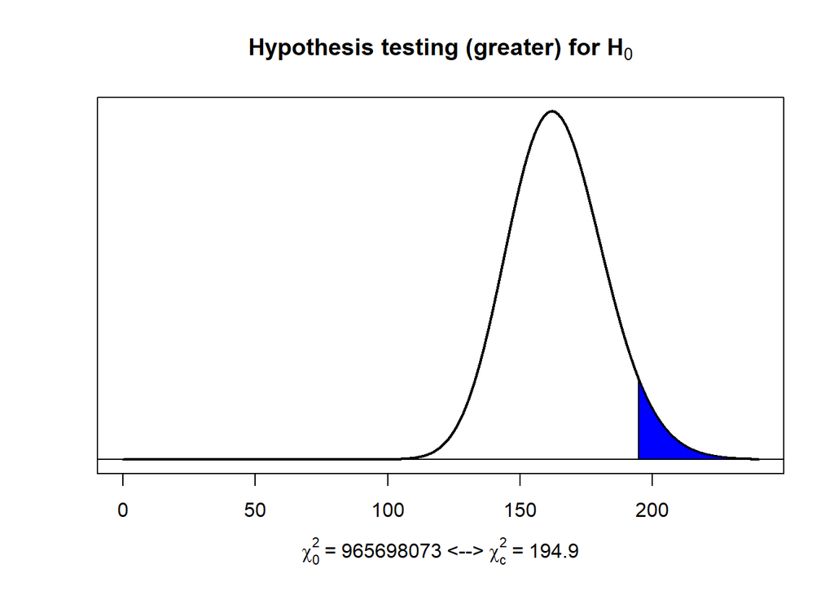

```r
#We can plot the hypothesis testing for goodness of fit using plot.hypothesis function that we defined before.
plotvar.hypothesis(Xsq$statistic,alpha=0.05,df1=164,type='c',alt='g')
```

…

### 3.2.4. Nonparametric Test Procedures

Nonparametric tests are also called distribution-free tests used for data does not follow a specific distribution. …

```r
#Write your codes here. Their results will appear after knitting the markdown file.
```

…

#### 3.2.4.1. Sign Test

The sign test is used to test the null hypothesis that the median of a distribution is equal to some value here median= mean is tested …

```r
"FOR CURRENT EXPENDITURES"
```

```
## [1] "FOR CURRENT EXPENDITURES"
```

```r
mediance <-(mean(data_22$CE))
expenditurece <-(data_22$CE)
alpha <- 0.05

SIGN.test(expenditurece, md = mediance)
```

```
##
##  One-sample Sign-Test
##
## data:  expenditurece
## s = 14, p-value = 0.04
## alternative hypothesis: true median is not equal to 467141360
## 95 percent confidence interval:
##     436697 421563901
## sample estimates:
## median of x
##    29873956
##
## Achieved and Interpolated Confidence Intervals:
##
##                   Conf.Level L.E.pt    U.E.pt
## Lower Achieved CI     0.9116 654652 334498045
## Interpolated CI       0.9500 436697 421563901
## Upper Achieved CI     0.9564 400164 436157692
```

```r
"FOR PERSONNEL EXPENDITURES"
```

```
## [1] "FOR PERSONNEL EXPENDITURES"
```

```r
medianpe <-(mean(data_22$PE))
expenditurepe <-(data_22$PE)
alpha <- 0.05

SIGN.test(expenditurepe, md = medianpe)
```

```
##
##  One-sample Sign-Test
##
## data:  expenditurepe
## s = 14, p-value = 0.04
## alternative hypothesis: true median is not equal to 394109263
## 95 percent confidence interval:
##     372755 362018022
## sample estimates:
## median of x
##    25915655
##
## Achieved and Interpolated Confidence Intervals:
##
##                   Conf.Level L.E.pt    U.E.pt
## Lower Achieved CI     0.9116 557737 285819432
## Interpolated CI       0.9500 372755 362018022
## Upper Achieved CI     0.9564 341749 374790266
```

```r
"FOR OTHER CURRENT EXPENDITURES"
```

```
## [1] "FOR OTHER CURRENT EXPENDITURES"
```

```r
medianoce <-(mean(data_22$OCE))
expenditureoce <-(data_22$OCE)
alpha <- 0.05

SIGN.test(expenditureoce, md = medianoce)
```

```
##
##  One-sample Sign-Test
##
## data:  expenditureoce
## s = 14, p-value = 0.04
## alternative hypothesis: true median is not equal to 73032098
## 95 percent confidence interval:
##     63942 59545879
## sample estimates:
## median of x
##     3958301
##
## Achieved and Interpolated Confidence Intervals:
##
##                   Conf.Level L.E.pt   U.E.pt
## Lower Achieved CI     0.9116  96915 48678614
## Interpolated CI       0.9500  63942 59545879
## Upper Achieved CI     0.9564  58415 61367426
```

```r
"FOR DEFENCE"
```

```
## [1] "FOR DEFENCE"
```

```r
mediand <-(mean(data_22$D))
expenditured <-(data_22$D)
alpha <- 0.05

SIGN.test(expenditured, md = mediand)
```

```
##
##  One-sample Sign-Test
##
## data:  expenditured
## s = 16, p-value = 0.2
## alternative hypothesis: true median is not equal to 68808754
## 95 percent confidence interval:
##     52312 76696230
## sample estimates:
## median of x
##     7662500
##
## Achieved and Interpolated Confidence Intervals:
##
##                   Conf.Level L.E.pt   U.E.pt
## Lower Achieved CI     0.9116  84150 68918000
## Interpolated CI       0.9500  52312 76696230
## Upper Achieved CI     0.9564  46975 78000000
```

```r
"FOR GNP"
```

```
## [1] "FOR GNP"
```

```r
mediangnp <-(mean(data_22$GNP))
expendituregnp <-(data_22$GNP)
alpha <- 0.05

SIGN.test(expendituregnp, md = mediangnp)
```

```
##
##  One-sample Sign-Test
##
## data:  expendituregnp
## s = 14, p-value = 0.04
## alternative hypothesis: true median is not equal to 2884909571
## 95 percent confidence interval:
##     2526930 2432701660
## sample estimates:
## median of x
##   175672105
##
## Achieved and Interpolated Confidence Intervals:
##
##                   Conf.Level  L.E.pt     U.E.pt
## Lower Achieved CI     0.9116 4037702 1907070964
## Interpolated CI       0.9500 2526930 2432701660
## Upper Achieved CI     0.9564 2273698 2520806747
```

```r
#Write your codes here. Their results will appear after knitting the markdown file.
```

…

#### 3.2.4.2. Wilcoxon Signed-Rank Test

The Wilcoxon signed-rank test is a non-parametric statistical hypothesis test used to compare two related samples. Here again median is tested …

```r
"FOR CURRENT EXPENDITURES"
```

```
## [1] "FOR CURRENT EXPENDITURES"
```

```r
mediance <-(mean(data_22$CE))
expenditurece <-(data_22$CE)
wilcox.test(expenditurece, alt="t",mu=mediance)
```

```
##
##  Wilcoxon signed rank exact test
##
## data:  expenditurece
## V = 428, p-value = 0.8
## alternative hypothesis: true location is not equal to 467141360
```

```r
"FOR PERSONNEL EXPENDITURES"
```

```
## [1] "FOR PERSONNEL EXPENDITURES"
```

```r
medianpe <-(mean(data_22$PE))
expenditurepe <-(data_22$PE)
wilcox.test(expenditurepe, alt="t",mu=medianpe)
```

```
##
##  Wilcoxon signed rank exact test
##
## data:  expenditurepe
## V = 424, p-value = 0.7
## alternative hypothesis: true location is not equal to 394109263
```

```r
"FOR OTHER CURRENT EXPENDITURES"
```

```
## [1] "FOR OTHER CURRENT EXPENDITURES"
```

```r
medianoce <-(mean(data_22$OCE))
expenditureoce <-(data_22$OCE)
wilcox.test(expenditureoce, alt="t",mu=medianoce)
```

```
##
##  Wilcoxon signed rank exact test
##
## data:  expenditureoce
## V = 445, p-value = 0.9
## alternative hypothesis: true location is not equal to 73032098
```

```r
"FOR DEFENCE"
```

```
## [1] "FOR DEFENCE"
```

```r
mediand <-(mean(data_22$D))
expenditured <-(data_22$D)
wilcox.test(expenditured, alt="t",mu=mediand)
```

```
##
##  Wilcoxon signed rank exact test
##
## data:  expenditured
## V = 430, p-value = 0.8
## alternative hypothesis: true location is not equal to 68808754
```

```r
"FOR GNP"
```

```
## [1] "FOR GNP"
```

```r
mediangnp <-(mean(data_22$GNP))
expendituregnp <-(data_22$GNP)
wilcox.test(expendituregnp, alt="t",mu=mediangnp)
```

```
##
##  Wilcoxon signed rank exact test
##
## data:  expendituregnp
## V = 352, p-value = 0.2
## alternative hypothesis: true location is not equal to 2884909571
```

…

#### 3.2.4.3. Wilcoxon Rank-Sum Test

```r
"FOR PERSONNEL EXPENDITURES AND OTHER CURRENT EXPENDITURES"
```

```
## [1] "FOR PERSONNEL EXPENDITURES AND OTHER CURRENT EXPENDITURES"
```

```r
axial<-cbind(data_22$PE, data_22$OCE); axial
```

```
##               [,1]        [,2]
##  [1,]        553.3       114.7
##  [2,]        627.1       149.5
##  [3,]        991.5       322.8
##  [4,]       1971.1       450.9
##  [5,]       3012.1       783.5
##  [6,]       3271.8      1129.2
##  [7,]       6032.0      1543.1
##  [8,]      10262.7      2143.2
##  [9,]      17229.9      2937.6
## [10,]      27676.0      4742.2
## [11,]      39041.3      6925.2
## [12,]      65663.5     10223.4
## [13,]     108093.1     21020.9
## [14,]     206942.8     40693.4
```

[output cut: 28 more lines]

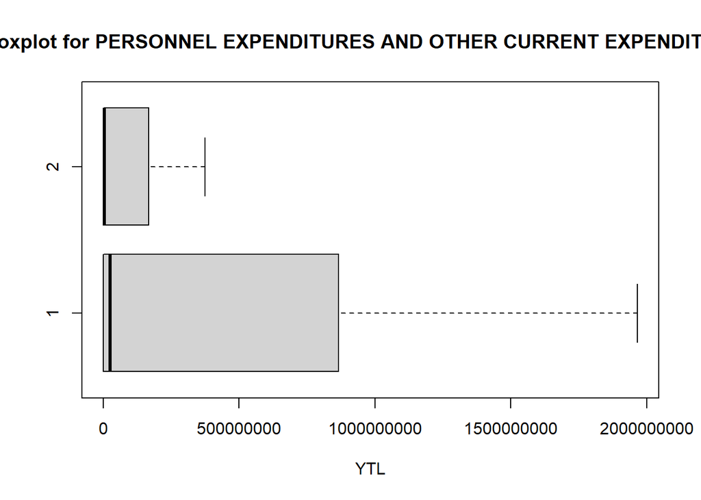

```r
boxplot(axial,horizontal=T,xlab="YTL",main="Boxplot for PERSONNEL EXPENDITURES AND OTHER CURRENT EXPENDITURES")
```

```r
wilcox.test(data_22$PE, data_22$OCE, alt="t", exact=F, correct=F)
```

```
##
##  Wilcoxon rank sum test
##
## data:  data_22$PE and data_22$OCE
## W = 1106, p-value = 0.05
## alternative hypothesis: true location shift is not equal to 0
```

```r
"FOR PERSONNEL EXPENDITURES AND DEFENCE"
```

```
## [1] "FOR PERSONNEL EXPENDITURES AND DEFENCE"
```

```r
axial<-cbind(data_22$PE, data_22$D); axial
```

```
##               [,1]        [,2]
##  [1,]        553.3       143.6
##  [2,]        627.1       124.9
##  [3,]        991.5       198.9
##  [4,]       1971.1       325.8
##  [5,]       3012.1       548.6
##  [6,]       3271.8       757.9
##  [7,]       6032.0      1261.7
##  [8,]      10262.7      2537.9
##  [9,]      17229.9      3598.4
## [10,]      27676.0      4982.0
## [11,]      39041.3      5980.0
## [12,]      65663.5      8564.7
## [13,]     108093.1     12550.0
## [14,]     206942.8     20140.0
```

[output cut: 28 more lines]

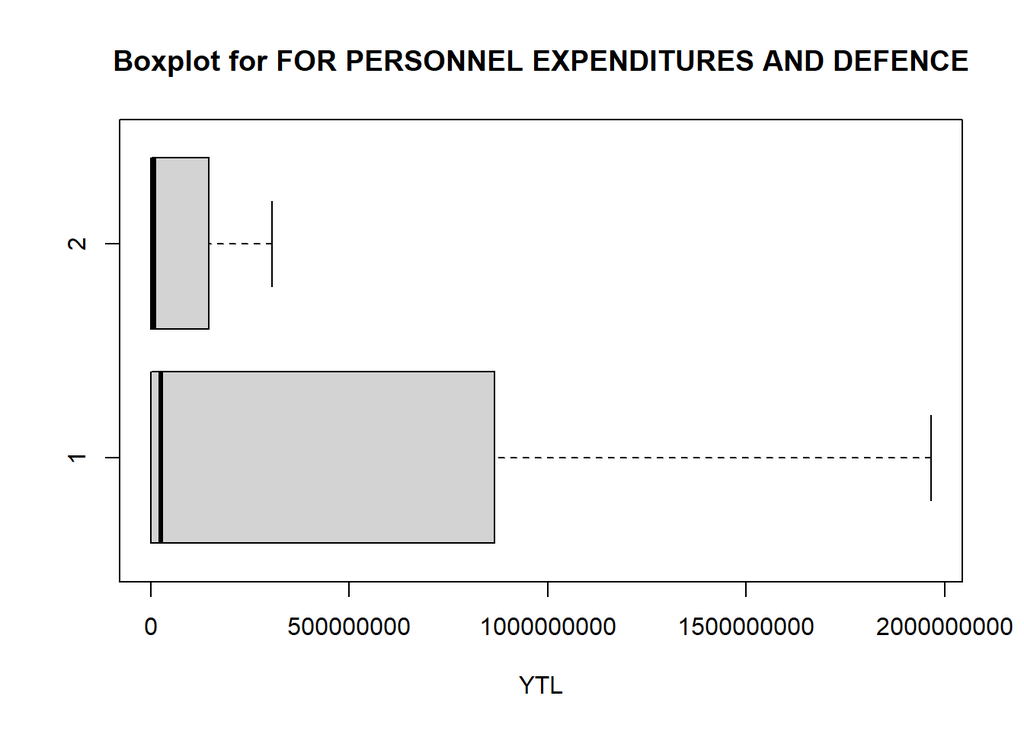

```r
boxplot(axial,horizontal=T,xlab="YTL",main="Boxplot for FOR PERSONNEL EXPENDITURES AND DEFENCE")
```